# Rotavirus Survey in Nairobi Kenya

Rotavirus is the most common cause of severe gastroenteritis among children worldwide. In 2013 WHO estimated that there was about 215,000 deaths from Rotavirus. This is lower from the estimated 528,000 deaths from rotavirus in 2010. Most of this deeaths occur in the Sub saharan Africa. In 2013 India, Nigeria, Democratic Republic of Congo and Pakistan accounted for about 49% of this deaths. Although vaccination is the most effective way of combacting rotavirus, poor countries are often affected due to lack of good health care.

In Kenya rotavirus is estimated to cause 3908 deaths, 3015 outpatient visits and 279 hospitalisation per 100,000 children under the age of 5. It is also estimated that this costs the kenyan economy $11 million. In 2014 the government of Kenya introduced a routine rotavirus immunisation. The vaccine is now available to the public for free through public hospitals. This is a big milestone for kenya as the World Bank estimates that 40% of Kenyans live under a dollar per day. The cost of one dose of Rotavirus vaccine through private hospitals is about $50. This is shows that almoast half of the population might have been unable to afford this vaccine.

After the introduction of this vaccine in public hospitals several studies have been conducted to find out the impact of the vaccine. The main study conducted is done by Kenya Medical Research Institue, Center for Disease Control(United States of America) and funded by Bill and Melinda Gates foundation. The research is expected to end by the end of 2017.

In December 2016 Mbagathi hospital carried out a research on the factors that influenced parents to vaccinate their children. I will use this data set to try and see what factors Influence vaccination in Kenya. The data set is available in both excel, SPSS and csv format.

```r
# reading data from github

rotavirus <- read.csv("https://raw.githubusercontent.com/Mburu-m/rotavirus-survey-data/master/rotavirus.csv")
```

```r
library(plyr)
library(dplyr)
# convert distance into a factor variable
# convert immunization variable into binary variable
#those who have completed the two doses of immunization vs those who have not been immunised

rotavirus <- rotavirus %>% mutate(distance = cut(distance, breaks = c(0, 5, 10, 17), include.lowest = T,
                                                 right = T, labels = c("<= 5", "6 - 10", "> 10")),
                                  immunicard = ifelse(immunicard == "completed", "Immunized", "Not immunized"))
```

The following table shows frequencies for demographic variables. About 68% of the mothers interviewed had a secondary or tertially education. Most of them gave birth at a health facility with only 6.5% of the women having gave birth at home. This might be as a results of introduction of free maternity services in Kenya in the year 2013. The table also displays marital and religion of the respondents interviewed.

```r
#get a subset of demographic variables

demographics <- rotavirus[, c(3, 4, 5, 6, 10)]

#convert the demographic df into long format
# makes calculating frequencies easier
library(reshape2);
demographicsTall <- melt(demographics, id.vars = "immunicard")

demographicsSummary <- demographicsTall[!is.na(demographicsTall$value),] %>% group_by(variable, value) %>%
  summarise(freq = n()) %>% mutate(percent = round(freq/sum(freq) * 100, 2 ))


knitr::kable(demographicsSummary)
```

| variable | value | freq | percent |
| --- | --- | --- | --- |
| marstatus | Divorced | 14 | 4.00 |
| marstatus | Married | 267 | 76.29 |
| marstatus | Separated | 3 | 0.86 |
| marstatus | Single | 62 | 17.71 |
| marstatus | Widow | 4 | 1.14 |
| religion | Catholic | 121 | 34.67 |
| religion | Indigenous | 14 | 4.01 |
| religion | Muslim | 32 | 9.17 |
| religion | None | 9 | 2.58 |
| religion | Protestant | 173 | 49.57 |
| education | None | 5 | 1.43 |
| education | Primary | 106 | 30.37 |
| education | Secondary | 154 | 44.13 |
| education | Tertiary | 84 | 24.07 |
| delivery | Health facility delivery | 327 | 93.43 |
| delivery | Home delivery | 23 | 6.57 |

One of the objectives of the survey was to seek if parents knew the dangers and symptoms of rotavirus. They were 12 questions in the survey that sought to adress this.These also included questions that sought to see if parents understood at what age they should get their kids immunized. The highest score was 16 indicating that the parent was knowledgeable about the dangers and symptoms of rotavirus. Also when she should take her child for immunization.

```r
#12 knowledge questions
#sum thm to come up with
#the total score.
# the highest score is 16
# read data without converted factor labels
#


rota <- read.csv( "https://raw.githubusercontent.com/Mburu-m/rotavirus-survey-data/master/rotavirus2.csv")

rota[rota==99] <- NA
knowledge <- rowSums(rota[, 19:30], na.rm = T)

rotavirus$knowledge <- knowledge
```

Knowledge scores has a bimodal distribution. There are those who were very knowledgeable about rotavirus and those who didn’t know much about the disease.

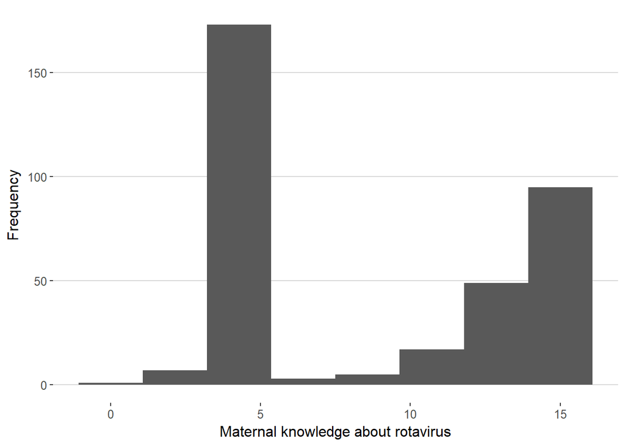

```r
#load library ggplot2
#for plotting

library(ggplot2)
if (!require("ggthemes")) install.packages("ggthemes")
library(ggthemes)

#histogram for knowledge about rotavirus

hist_knowledge <- ggplot(rotavirus, aes(x = knowledge)) +
  geom_histogram(bins = 8) + theme_hc()+
  labs(list(x = "Maternal knowledge about rotavirus", y = "Frequency"))


hist_knowledge
```

The data shows that about 89.15% of the parents interviwed had their children immunized. This is consistent with [research done in Kiambu county in 2016](https://www.ncbi.nlm.nih.gov/pmc/articles/PMC5404664/) where the vaccination level was at 82%. However, there are other areas in Kenya where vaccination is very low. For instance, in the reaserch mentioned in Mbita county only 53.53% of the children age between 12 months to 13 months were fully immunized.

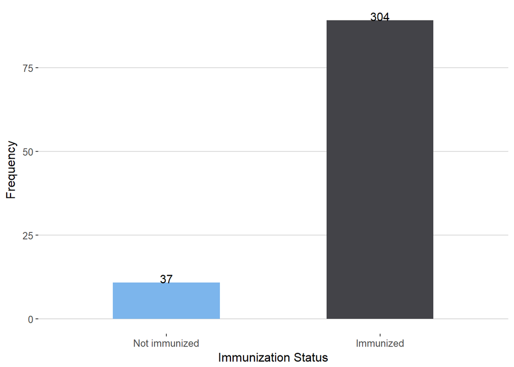

```r
# bargraph for immunisation variable
rotavirus$immunicard <- factor(rotavirus$immunicard, levels = c("Not immunized", "Immunized" ))

immunizationPercentage <- rotavirus[!is.na(rotavirus$immunicard),] %>% group_by(immunicard) %>%
  summarise(freq = n()) %>% mutate(percent = round(freq/sum(freq) * 100, 2 ))

immunized_bar <- ggplot(immunizationPercentage, aes(x = immunicard, y = percent, fill = immunicard)) +
  geom_bar(stat = "identity", width = 0.5) + theme_hc()+
  geom_text(aes(immunicard, percent, label = freq), position =  position_dodge(width = 0.5),
            size = 4, vjust = 0.05)+
  labs(list(x = "Immunization Status", y = "Frequency"))+
  scale_fill_hc(name = "")

immunized_bar <- immunized_bar + theme(legend.position = "none")

immunized_bar
```

The bar graph below compares immunisation between gender of the child. There are no differences between genders when it comes to immunization.

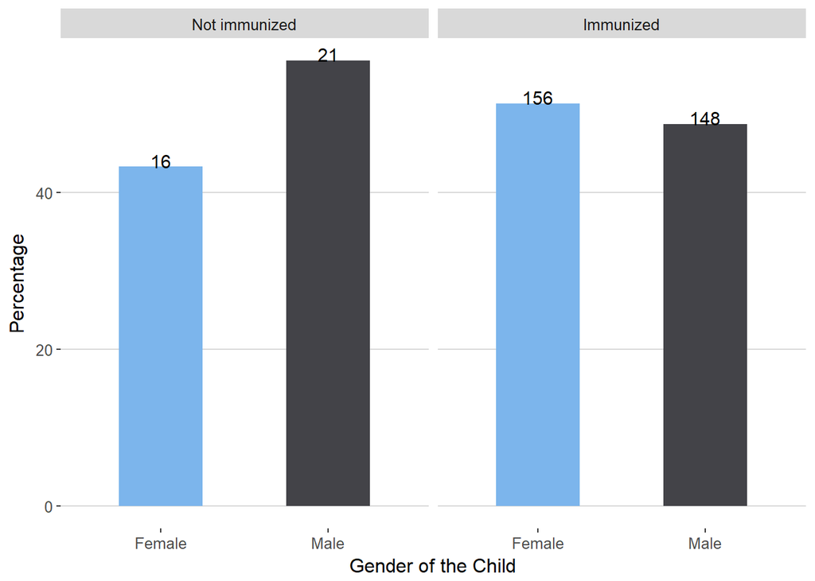

```r
#find the percentage for those immunised

immuniGendPerc <- rotavirus[!is.na(rotavirus$immunicard),] %>% group_by(immunicard, gender) %>%
  summarise(freq = n()) %>% mutate(percent = round(freq/sum(freq) * 100, 2 ))

immunized_gender_bar <- ggplot(immuniGendPerc, aes(x = gender, y = percent, fill = gender)) +
  geom_bar(stat = "identity", width = 0.5) +facet_wrap(~immunicard) +  theme_hc()+
  geom_text(aes(gender, percent, label = freq), position =  position_dodge(width = 0.5),
            size = 4, vjust = 0.05)+
  labs(list(x = "Gender of the Child", y = "Percentage"))+
  scale_fill_hc(name = "")

immunized_gender_bar <- immunized_gender_bar + theme(legend.position = "none")

immunized_gender_bar
```

A logistic regression was fitted to see how education, distance from a health center, maternal age, maternal knowledge about vaccination affect vaccination. Of the four variables a mothers knowledge about rotavirus is the best determinant of whether a parent had immunized her child. Infact a 1 point increase in a mothers knowledge increases the chances of vaccination by 18%. Maternal age was also significant. Older parents are likely to have immunised there children compared to the younger ones. This might be as a result of experience. It might also be a social economic status. Education did not have an effect on whether a parent has immunized her child, neither did distance. Incase of distance, given that this is the capital of Kenya, it is developed than the rural areas, hence we expect that there are health facilities nearby. In rural settings where sometimes people have to walk miles to find a health facility distance from a health facility might have played a role.

```r
if (!require("xtable")) install.packages("xtable")
library(xtable)

#fit logistic model
fitglm <- glm(immunicard ~ matage + knowledge   +  distance + education,
              data = rotavirus, family = "binomial")



ccf <- cut(rotavirus$matage, breaks = c(0, 24, 44), right = T)
summary(fitglm) %>% xtable() %>% knitr::kable()
```

|  | Estimate | Std. Error | z value | Pr(>\|z\|) |
| --- | --- | --- | --- | --- |
| (Intercept) | -1.2057144 | 1.4768197 | -0.8164262 | 0.4142564 |
| matage | 0.0759687 | 0.0392374 | 1.9361320 | 0.0528515 |
| knowledge | 0.1878023 | 0.0560312 | 3.3517480 | 0.0008030 |
| distance6 - 10 | -0.3571904 | 0.4064216 | -0.8788668 | 0.3794735 |
| distance> 10 | 0.4008827 | 0.7934300 | 0.5052527 | 0.6133813 |
| educationPrimary | -0.0960098 | 1.2181680 | -0.0788149 | 0.9371798 |
| educationSecondary | 0.0940388 | 1.2140725 | 0.0774573 | 0.9382597 |
| educationTertiary | 0.8955903 | 1.3420762 | 0.6673170 | 0.5045697 |

```r
drop1(fitglm, test = "Chisq") %>% xtable() %>% knitr::kable()
```

|  | Df | Deviance | AIC | LRT | Pr(>Chi) |
| --- | --- | --- | --- | --- | --- |
|  | NA | 197.0117 | 213.0117 | NA | NA |
| matage | 1 | 201.1665 | 215.1665 | 4.154735 | 0.0415183 |
| knowledge | 1 | 212.5873 | 226.5873 | 15.575542 | 0.0000793 |
| distance | 2 | 198.2604 | 210.2604 | 1.248659 | 0.5356205 |
| education | 3 | 199.4011 | 209.4011 | 2.389398 | 0.4956111 |

From the tree model, we can see that those who had a knowledge score of 10.5 and above, over 90% had immunized their children. From a sample of 350, 150 of them had scored 10.5 and above and in that group almost all of them had immunized their children. This shows how effective educating parents about benefits of vaccination and disease symptoms can improve percentage of immunized population in Sub Saharan Africa. The next important variable from the tree model is maternal age, Mothers who are 28 years and older have higher percentage of immunized children than their younger counterparts.

```r
#road rpart for decision trees

library(rpart)
#install and load partykit to plot nice trees

if (!require("partykit")) install.packages("partykit")
library(partykit)

#change factor lables to 0 and 1
#it makes the tree diagram look less clutered

rotavirus$immunicard2 <- factor(rotavirus$immunicard, levels = c("Not immunized", "Immunized"),
                                 labels = c(0, 1))
fit_tree <- rpart(immunicard2~ matage + knowledge + distance + education,
                  control= rpart.control(minsplit=5, minbucket=5, cp=0.006), data = rotavirus)
```

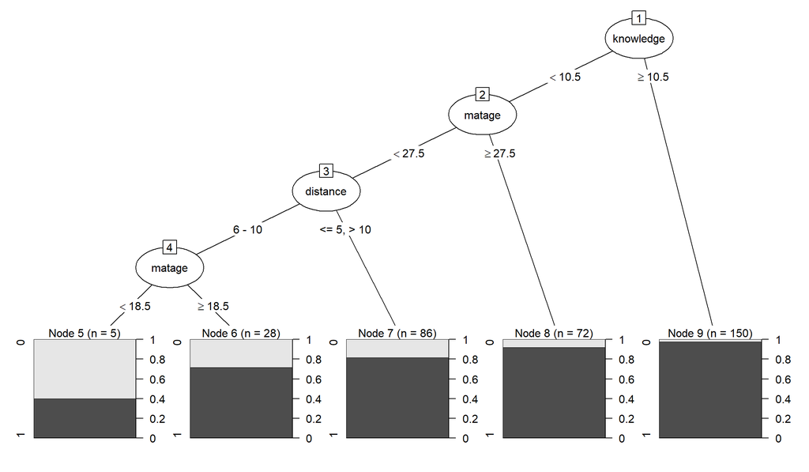

```r
plot(as.party(fit_tree))
```

We can use the desion tree cut points to convert knowledge and maternal age into categorical variable we can then visualize this to see how maternal age and knowledge affect immunisation.

```r
# converting knowledge and maternal age  into a factor variable

rotavirus <- rotavirus %>% mutate(knowledge_cat = cut(knowledge, breaks = c(0, 11, 16),
                                                     right = F, include.lowest = T,
                                                     labels = c("< 11", ">= 11")),
                                  matage_cat =cut(matage, breaks = c(0, 28, 44),
                                                  right = F, include.lowest = T,
                                                  labels = c("< 28", ">= 28")))
```

From the bar graph, 149 women out of 340 who were interviewed had a knowledge score of 10.5 and above. In this sample 145 women had their children immunized. That is about 97.3% of those who had higher score about vaccination and rotavirus symptoms had immunized their children. There were 74 women in the sample who were 28 years and above in that sample 73 had immunized their children. Those who were younger than 28 years and had a score of less than 10 had the highest percentage (7.94$) of un immunized children.

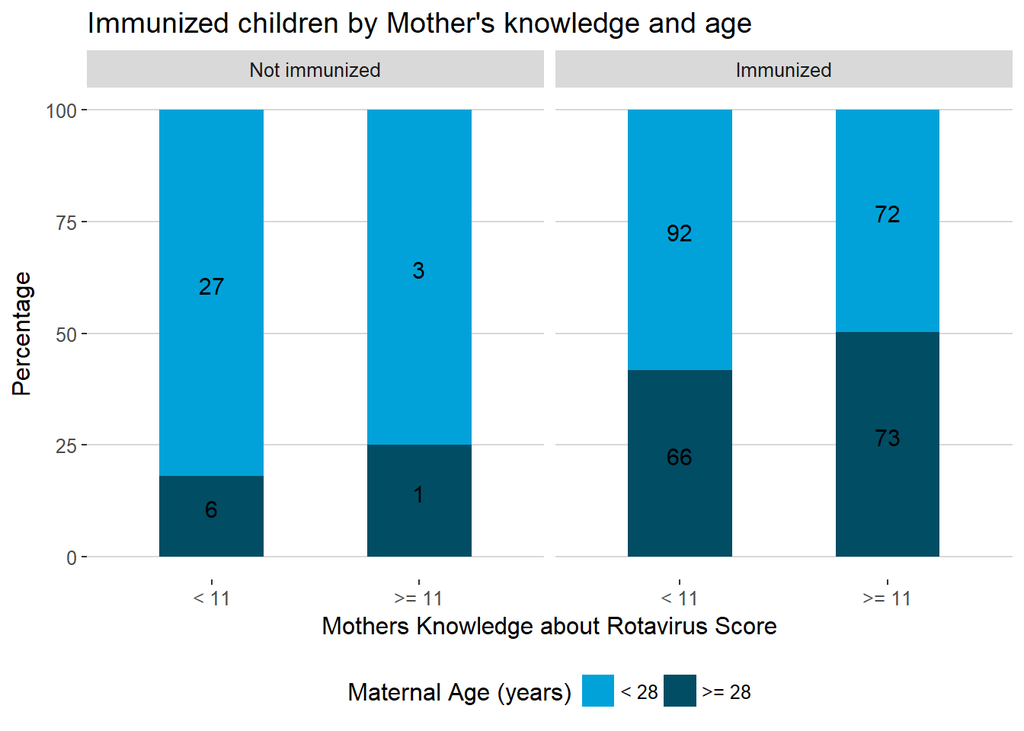

```r
immuniAgeKnowledgePerc <- rotavirus[!is.na(rotavirus$immunicard) &!is.na(rotavirus$matage_cat),] %>%
  group_by(immunicard , knowledge_cat, matage_cat) %>%
  summarise(freq = n()) %>% mutate(percent = round(freq/sum(freq) * 100, 2 ))

immuniAgeKnowledgePercbar <- ggplot(immuniAgeKnowledgePerc, aes(x = knowledge_cat, y = percent, fill = matage_cat)) +
  geom_bar(stat = "identity", width = 0.5) +facet_wrap(~immunicard) +  theme_hc()+
  geom_text(aes(knowledge_cat, percent, label = freq), position =  position_stack(vjust = 0.5),
            size = 4, vjust = 0.05)+
  labs(list(x = "Mothers Knowledge about Rotavirus Score", y = "Percentage",
            title ="Immunized children by Mother's knowledge and age"))+
  scale_fill_economist(name = "Maternal Age (years)")

immuniAgeKnowledgePercbar
```

From this, we can see how important educating people on vaccines is. Governments should thus make sure they invest in education programs. For instance they can do it via radio shows, television, social media and through health care practioners.